# Corrélations fonctionelles - MB-PLS

## 1.7 AMR_ville_C3G_R

```r
y <- "AMR_ville_C3G_R"
time_period <- 2018:2022
var <- selvar_AMR_ville_C3G
Nb.Base <- 3

automatisation_block(y = y, blocks = blocks, time_period = time_period, var = var,
                     Nb.Base = Nb.Base)
```

### 1.7.1 AMC

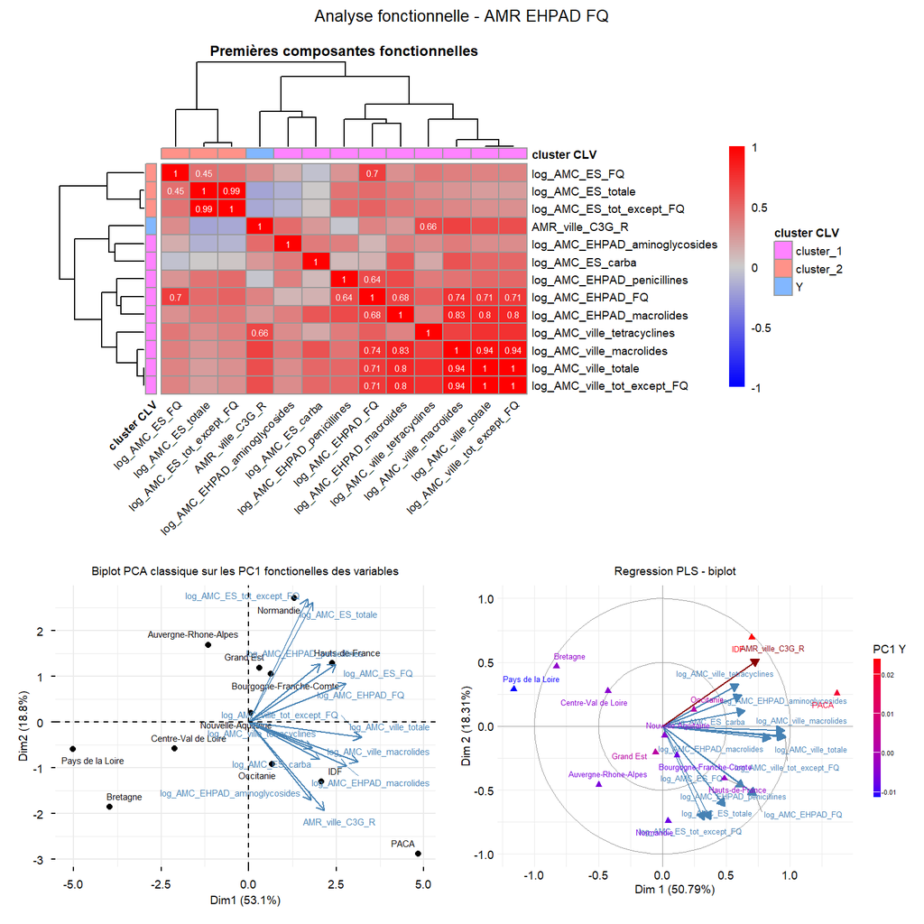

### 1.7.2 socioeco

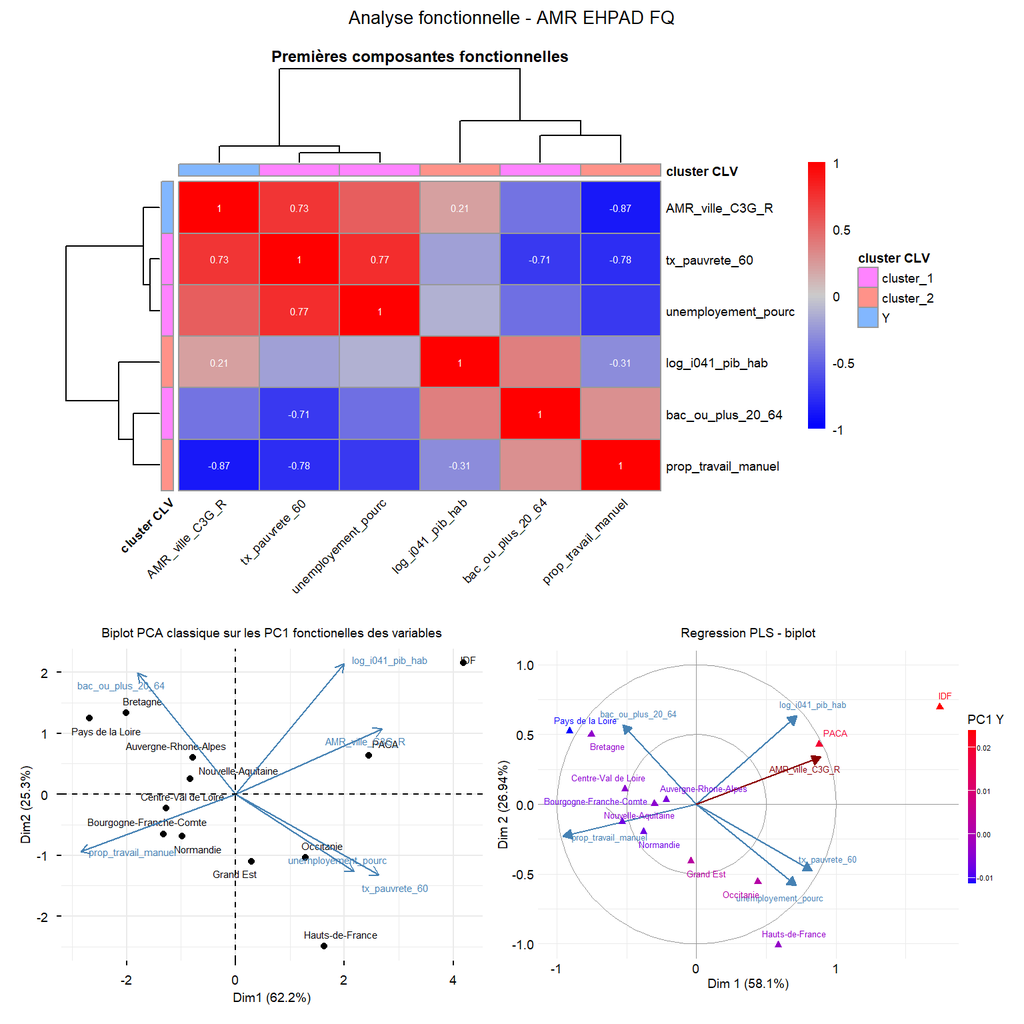

### 1.7.3 soin

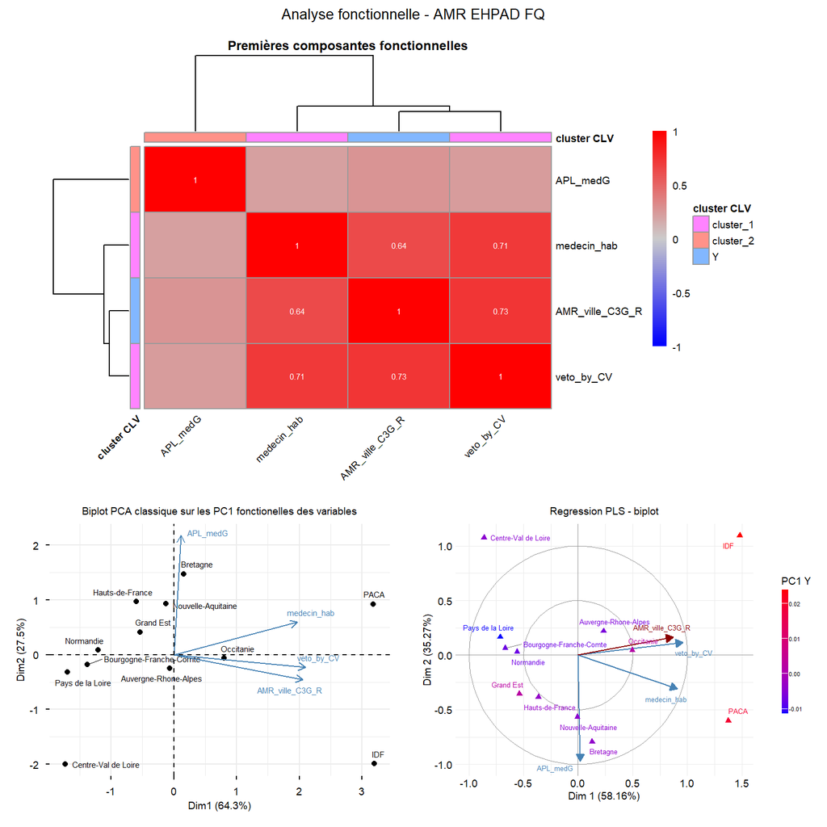

### 1.7.4 lifestyle

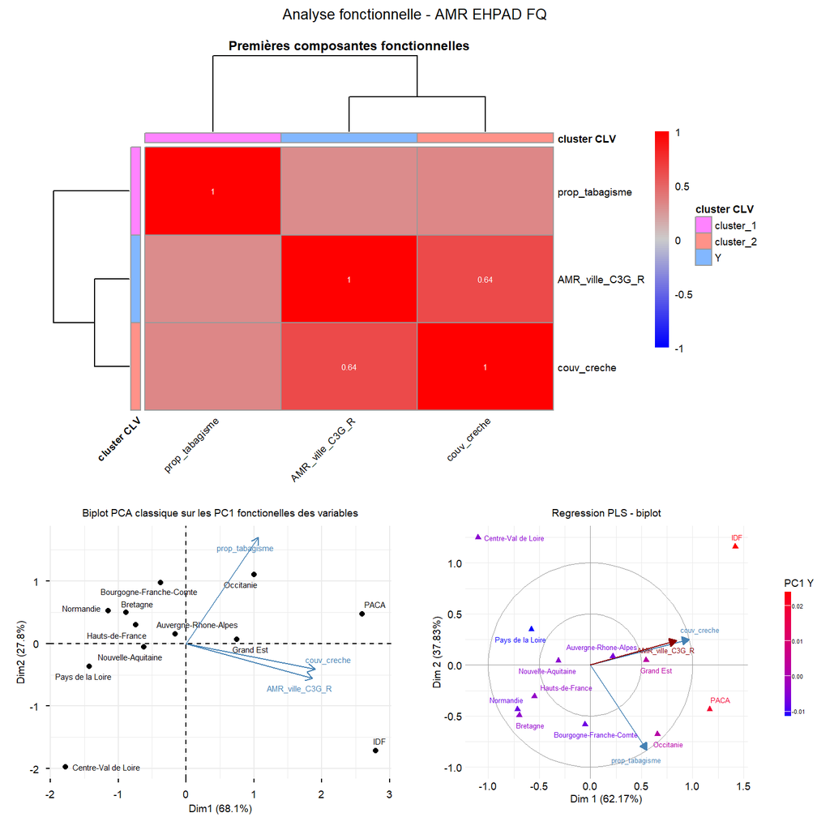

### 1.7.5 env

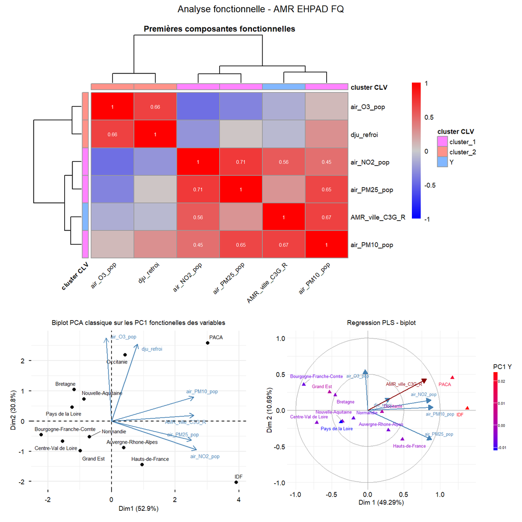

### 1.7.6 agri

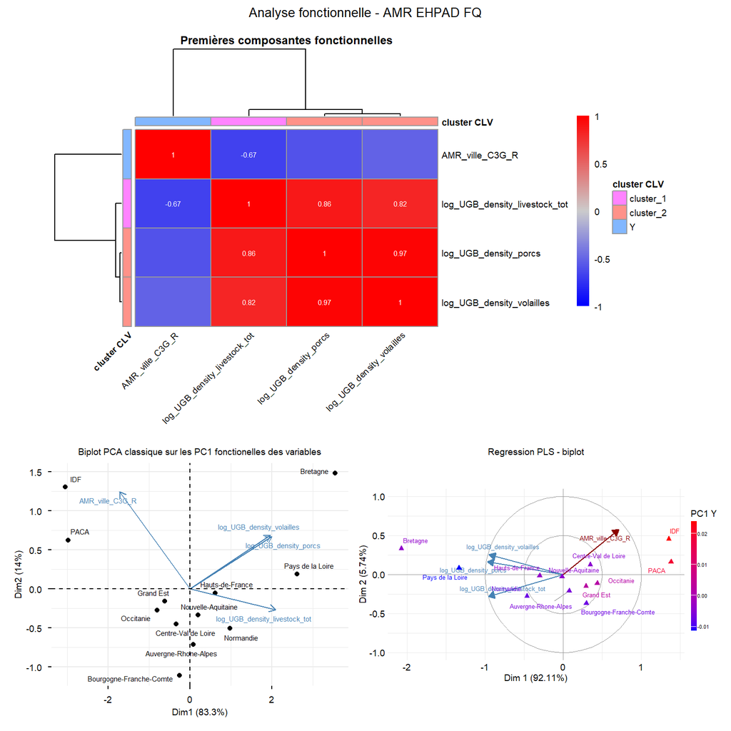

# 2 Mb-PLS

## 2.1 AMR_EHPAD_FQ_R

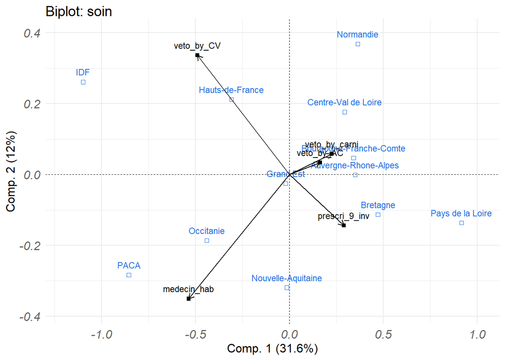

```r
sum.var <- openxlsx::read.xlsx("C:/Users/g.martet/Documents/functional_study/sum.var_AMR_EHPAD_FQ_R.xlsx")
rownames(sum.var) <- sum.var[,1]
sum.var <- sum.var[,-1]

# pour les blocks à une seule variables
res1 <- functional_correlation(var = selvar_AMR_EHPAD_FQ,
                       block = "socioeco", time_period = 2018:2022,
                       y = "AMR_EHPAD_FQ_R")


res2 <- functional_correlation(var = selvar_AMR_EHPAD_FQ,
                       block = "demo", time_period = 2018:2022,
                       y = "AMR_EHPAD_FQ_R")

sum.var <- cbind.data.frame(sum.var, res1[[2]], res2[[2]])
sum.var <- sum.var[,-which(duplicated(colnames(sum.var)))]
#colnames(sum.var)

bl <- list(Y        = as.matrix(sum.var[, 1]),
           AMC      = as.matrix(sum.var[, 2:19]),
           soin     = as.matrix(sum.var[, 20:24]),
           lifestyle = as.matrix(sum.var[, 25:26]),
           env      = as.matrix(sum.var[, 27:31]),
           agri     = as.matrix(sum.var[, 32:38]),
           socioeco = as.matrix(sum.var[, 39, drop = FALSE]),
           demo     = as.matrix(sum.var[, 40, drop = FALSE]))

n_blocks <- length(bl)

# Connexion supervisée : chaque bloc X connecté à Y seulement
# Y est le bloc 1
connection <- matrix(0, nrow = n_blocks, ncol = n_blocks,
                     dimnames = list(names(bl), names(bl)))
connection[1, 2:n_blocks] <- 1
connection[2:n_blocks, 1] <- 1

out.mbpls <- rgcca(
  blocks     = bl,
  connection = connection,
  method     = "rgcca",
  tau        = rep(1, n_blocks),  # tau=1 = mode B = PLS
  ncomp      = c(1, rep(2, 5), rep(1, 2)),
  scheme     = "factorial",
  scale      = TRUE,
  verbose    = FALSE
)

plot(out.mbpls, type = "biplot", block = 3)
```

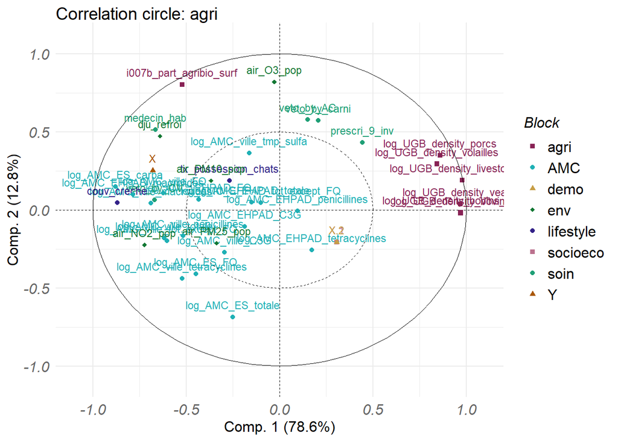

```r
plot(out.mbpls, type = "cor_circle", block = 6)
```

# 3 Tableau récapitulatif

```r
#importer les datasets
cls1 <- openxlsx::read.xlsx("C:/Users/g.martet/Documents/functional_study/cls.var_AMR_EHPAD_FQ_R.xlsx")
cls2 <- openxlsx::read.xlsx("C:/Users/g.martet/Documents/functional_study/cls.var_AMR_ES_FQ_R.xlsx")
cls3 <- openxlsx::read.xlsx("C:/Users/g.martet/Documents/functional_study/cls.var_AMR_ville_FQ_R.xlsx")
cls4 <- openxlsx::read.xlsx("C:/Users/g.martet/Documents/functional_study/cls.var_AMR_EHPAD_C3G_R.xlsx")
cls5 <- openxlsx::read.xlsx("C:/Users/g.martet/Documents/functional_study/cls.var_AMR_ES_C3G_R.xlsx")
cls6 <- openxlsx::read.xlsx("C:/Users/g.martet/Documents/functional_study/cls.var_AMR_ville_C3G_R.xlsx")

# let's go
big_tab <- correspondance_block
big_tab <- dplyr::left_join(big_tab, cls1, by = "variable")
big_tab <- dplyr::left_join(big_tab, cls2, by = "variable")
big_tab <- dplyr::left_join(big_tab, cls3, by = "variable")
big_tab <- dplyr::left_join(big_tab, cls4, by = "variable")
big_tab <- dplyr::left_join(big_tab, cls5, by = "variable")
big_tab <- dplyr::left_join(big_tab, cls6, by = "variable")

# ajustements pour les blocks de moins de une seule variable
# AMR EHPAD FQ R: blocks socioeco, demo 1 variable
big_tab[big_tab$block %in% c("socioeco", "demo") & big_tab$variable %in% selvar_AMR_EHPAD_FQ, "AMR_EHPAD_FQ_R"] <- "cluster_1"
# AMR ville C3G demo: une seule variable
big_tab[big_tab$block == "demo" & big_tab$variable %in% selvar_AMR_ville_C3G, "AMR_ville_C3G_R"] <- "cluster_1"

#openxlsx::write.xlsx(big_tab, file = "tableau_recapitulatif_clustvar.xlsx")

# représenter le tableau de manière jolie

# Palette de couleurs par cluster
cluster_colors <- c(
  "cluster_1" = "#AED6F1",  # bleu clair
  "cluster_2" = "#A9DFBF",  # vert clair
  "cluster_3" = "#F9E79F",  # jaune clair
  "cluster_4" = "#F5CBA7"   # orange clair
)

# Fonction pour colorier une cellule selon sa valeur
color_cell <- function(x) {
  x <- as.character(x)  # convertit NA en "NA" string
  dplyr::case_when(
    is.na(x) | x == "NA" ~ cell_spec(" ", background = "white",  color = "white"),
    x == "cluster_1"      ~ cell_spec(x,   background = "#AED6F1", color = "black"),
    x == "cluster_2"      ~ cell_spec(x,   background = "#A9DFBF", color = "black"),
    x == "cluster_3"      ~ cell_spec(x,   background = "#F9E79F", color = "black"),
    x == "cluster_4"      ~ cell_spec(x,   background = "#F5CBA7", color = "black"),
    TRUE                  ~ x
  )
}
# Appliquer la coloration sur toutes les colonnes de cluster
cols_cluster <- colnames(big_tab)[!(colnames(big_tab) %in% c("block", "variable"))]

big_tab_colored <- big_tab %>%
  dplyr::mutate(dplyr::across(dplyr::all_of(cols_cluster), color_cell))

# Taille des groupes par block (pour pack_rows)
order_blocks <- c("AMC", "socioeco", "soin", "lifestyle", "demo", "env", "agri")

group_sizes <- big_tab %>%
  dplyr::mutate(block = factor(block, levels = order_blocks)) %>%
  dplyr::arrange(block) %>%
  dplyr::group_by(block) %>%
  dplyr::summarise(n = n()) %>%
  tibble::deframe()


# Construction du tableau
big_tab_colored %>%
  dplyr::mutate(block = factor(block, levels = order_blocks)) %>%
  dplyr::arrange(block) %>%
  dplyr::select(-block) %>%
  kable(format = "html", escape = FALSE,
        col.names = c("Variable", cols_cluster),
        align = c("l", rep("c", length(cols_cluster)))) %>%
  kable_styling(bootstrap_options = c("striped", "hover", "condensed", "bordered"),
                full_width = FALSE,
                font_size = 11) %>%
  # Groupes par block
  pack_rows(index = group_sizes,
            label_row_css = "background-color: #2C3E50; color: white; font-weight: bold;") %>%
  column_spec(1, bold = TRUE, width = "12em") %>%
  scroll_box(width = "100%", height = "600px")
```

| Variable | AMR_EHPAD_FQ_R | AMR_ES_FQ_R | AMR_ville_FQ_R | AMR_EHPAD_C3G_R | AMR_ES_C3G_R | AMR_ville_C3G_R |
| --- | --- | --- | --- | --- | --- | --- |
| **AMC** |  |  |  |  |  |  |
| log_AMC_EHPAD_C3G | cluster_1 | cluster_1 | cluster_1 | cluster_1 | cluster_1 |  |
| log_AMC_EHPAD_FQ | cluster_1 | cluster_1 | cluster_2 | cluster_1 | cluster_1 | cluster_1 |
| log_AMC_EHPAD_aminoglycosides |  |  | cluster_2 |  |  | cluster_1 |
| log_AMC_EHPAD_macrolides | cluster_2 | cluster_2 | cluster_2 | cluster_2 |  | cluster_1 |
| log_AMC_EHPAD_penicillines | cluster_3 | cluster_1 | cluster_1 | cluster_1 |  | cluster_1 |
| log_AMC_EHPAD_tetracyclines | cluster_3 | cluster_3 |  |  | cluster_2 |  |
| log_AMC_EHPAD_tmp_sulfa |  | cluster_1 | cluster_1 | cluster_1 | cluster_1 |  |
| log_AMC_EHPAD_totale | cluster_3 | cluster_1 | cluster_1 | cluster_1 | cluster_1 |  |
| log_AMC_ES_FQ | cluster_1 | cluster_3 | cluster_2 | cluster_2 | cluster_2 | cluster_2 |
| log_AMC_ES_carba | cluster_2 | cluster_2 | cluster_2 | cluster_2 | cluster_3 | cluster_1 |
| log_AMC_ES_totale | cluster_1 | cluster_3 | cluster_3 | cluster_2 | cluster_2 | cluster_2 |
| log_AMC_ville_C3G | cluster_1 |  | cluster_2 |  | cluster_1 |  |
| log_AMC_ville_FQ | cluster_1 | cluster_2 | cluster_2 |  | cluster_3 |  |
| log_AMC_ville_aminoglycosides |  |  | cluster_2 |  | cluster_3 |  |
| log_AMC_ville_macrolides | cluster_2 | cluster_2 | cluster_2 | cluster_2 | cluster_3 | cluster_1 |
| log_AMC_ville_penicillines | cluster_2 | cluster_2 | cluster_2 | cluster_2 | cluster_3 |  |
| log_AMC_ville_tetracyclines | cluster_2 | cluster_2 | cluster_2 | cluster_2 | cluster_3 | cluster_1 |
| log_AMC_ville_tmp_sulfa | cluster_2 | cluster_2 | cluster_2 | cluster_2 |  |  |
| log_AMC_ville_totale | cluster_2 | cluster_2 | cluster_2 | cluster_2 | cluster_3 | cluster_1 |
| log_AMC_EHPAD_tot_except_FQ | cluster_3 | cluster_1 | cluster_1 | cluster_1 | cluster_1 |  |
| log_AMC_ES_tot_except_FQ |  | cluster_3 | cluster_3 |  | cluster_2 | cluster_2 |
| log_AMC_ville_tot_except_FQ | cluster_2 | cluster_2 | cluster_2 | cluster_2 | cluster_3 | cluster_1 |
| **socioeco** |  |  |  |  |  |  |
| EQI_st |  | cluster_1 | cluster_1 |  |  |  |
| bac_ou_plus_20_64 |  |  | cluster_2 |  | cluster_1 | cluster_1 |
| log_i041_pib_hab | cluster_1 | cluster_1 | cluster_1 | cluster_1 | cluster_2 | cluster_2 |
| prop_immig |  |  |  |  | cluster_2 |  |
| prop_travail_manuel |  | cluster_1 | cluster_1 | cluster_2 |  | cluster_2 |
| revenu_median |  |  |  |  |  |  |

[output cut: 54 more lines]

# 4 Régression (r)GSCA

L’idée ici est d’explorer la relation entre les différents blocs des premières composantes fonctionnelles de chaque variable. Nous allons utiliser pour cela la méthode GSCA (H. Hwang, Y. Takane, Generalized structured component analysis, Psychometrika 69 (2004) 81–99) avec le package R `gesca`(v 1.0.5). Nous allons utiliser un modèle réflectif, c’est à dire que chaque bloc sera caractérisé par une composante principale qui sera à la fois, une combinaison linéaire des PC1 fonctionelles ($t_k = X_kw_k$) et un prédicteur des variables d’origines ($X_k = t_kc_k$).

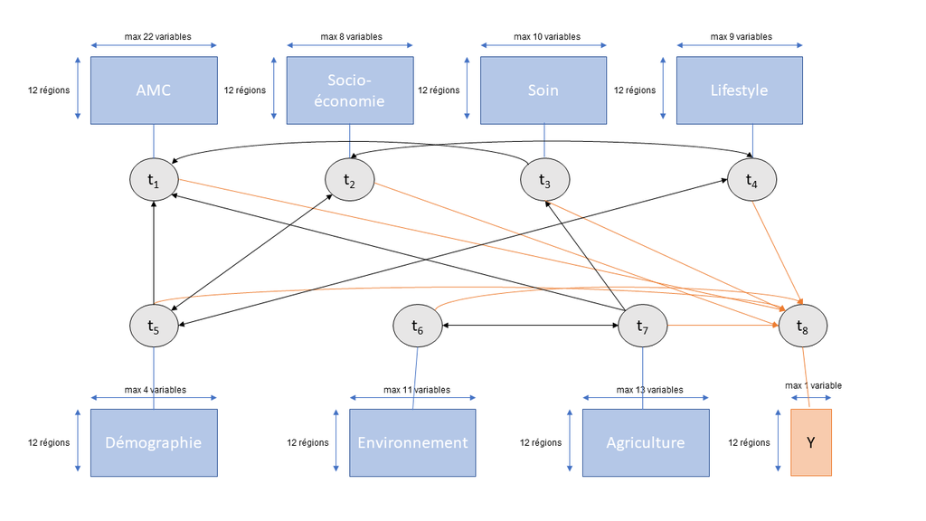

## 4.1 AMR EHPAD FQ

L’hypothèse d’unidimensionalité des blocks semble respecté. Pour le block lifestyle, le pourecentage de variance expliquée par PC1 est de seulement 54% car les deux variables couverture crèche et taux de possession de chats ne sont pas du tout corrélées.

```r
dat.func1 <- openxlsx::read.xlsx("sum.var2_AMR_EHPAD_FQ_R.xlsx")
rownames(dat.func1) <- dat.func1[, 1]
dat.func1 <- dat.func1[,-1]

# y <- "AMR_EHPAD_FQ_R"
# time_period <- 2018:2022
# var <- selvar_AMR_EHPAD_FQ
# Nb.Base <- 5
#
# res1 <- functional_correlation(var = var,
#                         block = "socioeco", time_period = time_period, y = y,
#                         Nb.Base = Nb.Base)
#
# res2 <- functional_correlation(var = var,
#                         block = "demo", time_period = time_period, y = y,
#                         Nb.Base = Nb.Base)
#
# dat.func1 <- cbind.data.frame(dat.func1,
#                   log_i041_pip_hab = res1[[7]][, 2],
#                   pop_75_plus_prop = res2[[7]][, 2])
#
# openxlsx::write.xlsx(dat.func1, file = paste0("sum.var2_", y, ".xlsx"), rowNames = TRUE)

dat.func1 <- scale(dat.func1) # standardisation

MyModel <- paste(
  paste("Y =~", colnames(dat.func1)[1]),
  "AMC =~ log_AMC_EHPAD_FQ + log_AMC_ville_totale + log_AMC_EHPAD_tot_except_FQ",
  "socioeco =~ log_i041_pip_hab",
  "soin =~ veto_by_AC + medecin_hab",
  "lifestyle =~ couv_creche + tx_possession_chats",
  "demo =~ pop_75_plus_prop",
  "env =~ air_NO2_pop + air_O3_pop",
  "agri =~ log_UGB_density_bovine_all + log_UGB_density_porcs + i007b_part_agribio_surf",
  "Y ~ AMC + soin + lifestyle + env + agri",
  "AMC ~ soin + demo + agri",
  "soin ~ agri",
  "socioeco ~ lifestyle + demo",
  "lifestyle ~ socioeco + demo",
  "demo ~ lifestyle + socioeco",
  "env ~  agri",
  "agri ~ env",
  sep = "\n\t\t"
)

MyModel2 <- paste(
  paste("Y =~", colnames(dat.func1)[1]),
  "AMC =~ log_AMC_EHPAD_FQ + log_AMC_ville_totale + log_AMC_EHPAD_tot_except_FQ",
  "socioeco =~ log_i041_pip_hab",
  "soin =~ veto_by_AC + medecin_hab",
  "lifestyle =~ couv_creche + tx_possession_chats",
  "demo =~ pop_75_plus_prop",
  "env =~ air_NO2_pop + air_O3_pop",
  "agri =~ log_UGB_density_bovine_all + log_UGB_density_porcs + i007b_part_agribio_surf",
  "Y ~ AMC + soin + lifestyle + env + agri + socioeco + demo",
  "AMC ~ soin + demo + agri + lifestyle + env + socioeco",
  "soin ~ AMC + demo + agri + lifestyle + env + socioeco",
  "demo ~ soin + AMC + agri + lifestyle + env + socioeco",
  "agri ~ soin + demo + AMC + lifestyle + env + socioeco",
  "lifestyle ~ soin + demo + agri + AMC + env + socioeco",
  "env ~ soin + demo + agri + lifestyle + AMC + socioeco",
  "socioeco ~ soin + demo + agri + lifestyle + env + AMC",
  sep = "\n\t\t"
)

# retrouver solve.default(t(X) %*% X, t(X) %*% Y %*% t(e))
# X <- as.matrix(dat.func1[, c(1, 3, 17, 18, 39, 20, 24, 25, 26, 40, 27, 28, 32, 35, 38)])
# A <- t(X)%*%X
# det(A)

# Hypothèse d'unidimensionalité des blocks
Xnorm.block <- list(dat.func1[,which(colnames(dat.func1) %in% c("log_AMC_EHPAD_FQ", "log_AMC_ville_totale", "log_AMC_EHPAD_tot_except_FQ"))],
                    dat.func1[,which(colnames(dat.func1) %in% c("log_i041_pip_hab"))],
                    dat.func1[,which(colnames(dat.func1) %in% c("veto_by_AC", "medecin_hab"))],
                    dat.func1[,which(colnames(dat.func1) %in% c("couv_creche", "tx_possession_chats"))],
                    dat.func1[,which(colnames(dat.func1) %in% c("pop_75_plus_prop"))],
                    dat.func1[,which(colnames(dat.func1) %in% c("air_NO2_pop", "air_O3_pop"))],
                    dat.func1[,which(colnames(dat.func1) %in% c("log_UGB_density_bovine_all", "log_UGB_density_porcs", "i007b_part_agribio_surf"))]
                    )

nb.block <- length(Xnorm.block)
order_blocks <- c("AMC", "socioeco", "soin", "lifestyle", "demo", "env", "agri")
eigen <- lapply(1:nb.block, function(k) FactoMineR::PCA(Xnorm.block[[k]], scale.unit = TRUE, ncp = 2, graph = F)$eig)
for(i in 1:nb.block){
  print(paste0("Block =", order_blocks[[i]]))
  print(eigen[[i]])
}
```

```
## [1] "Block =AMC"
##        eigenvalue percentage of variance cumulative percentage of variance
## comp 1  2.4176224              80.587413                          80.58741
## comp 2  0.3516206              11.720685                          92.30810
## comp 3  0.2307570               7.691901                         100.00000
## [1] "Block =socioeco"
##        eigenvalue percentage of variance cumulative percentage of variance
## comp 1          1                    100                               100
## [1] "Block =soin"
##        eigenvalue percentage of variance cumulative percentage of variance
## comp 1  1.4285193               71.42596                          71.42596
## comp 2  0.5714807               28.57404                         100.00000
## [1] "Block =lifestyle"
##        eigenvalue percentage of variance cumulative percentage of variance
## comp 1  1.0869165               54.34582                          54.34582
## comp 2  0.9130835               45.65418                         100.00000
## [1] "Block =demo"
##        eigenvalue percentage of variance cumulative percentage of variance
## comp 1          1                    100                               100
## [1] "Block =env"
##        eigenvalue percentage of variance cumulative percentage of variance
## comp 1  1.4989815               74.94907                          74.94907
## comp 2  0.5010185               25.05093                         100.00000
## [1] "Block =agri"
##        eigenvalue percentage of variance cumulative percentage of variance
## comp 1  2.0096893              66.989642                          66.98964
## comp 2  0.7651714              25.505714                          92.49536
## comp 3  0.2251393               7.504644                         100.00000
```

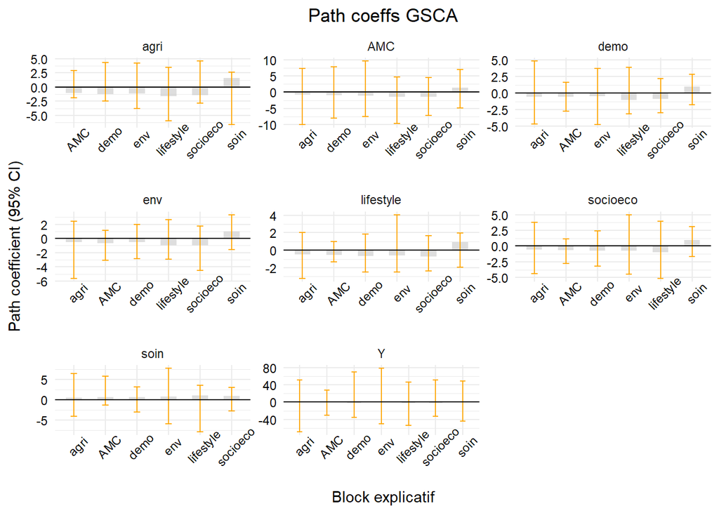

```r
# Le modèle
mod <- gesca::gesca.run(MyModel2, dat.func1, nbt = 0)

# Bootstrap manuel
set.seed(123)
n     <- nrow(dat.func1)
nbt   <- 100
boot_pc <- mod$mB
boot_load <- mod$mC

for (i in 1:nbt) {
  ok <- FALSE
  attempts <- 0

  while (!ok && attempts < 20) {
    idx      <- sample(n, n, replace = TRUE)
    dat_boot <- dat.func1[idx, ]

    result <- tryCatch(
      gesca.run(MyModel2, dat_boot, nbt = 0),
      error = function(e) NULL
    )

    if (!is.null(result)) {
      ok <- TRUE
      boot_pc <- cbind(boot_pc, result$mB)
      boot_load <- cbind(boot_load, result$mC)
    }
    attempts <- attempts + 1
  }

  if (!ok) warning(paste("Échantillon", i, "non convergé après 20 tentatives"))
}

# path coeff bootstrap
boot_pc <- boot_pc[,-1]
IC_low <- c()
IC_high <- c()
for (i in 1:nrow(boot_pc)){
  Q <- quantile(boot_pc[i,], probs = c(0.025, 0.975))
  IC_low <- c(IC_low, Q[1])
  IC_high <- c(IC_high, Q[2])
}

paths <- data.frame(
  path = c(
    "Y~AMC",
    "socioeco~AMC",
    "soin~AMC",
    "lifestyle~AMC",
    "demo~AMC",
    "env~AMC",
    "agri~AMC",
    "Y~socioeco",
    "AMC~socioeco",
    "soin~socioeco",
    "lifestyle~socioeco",
    "demo~socioeco",
    "env~socioeco",
    "agri~socioeco",
    "Y~soin",
    "AMC~soin",
    "socioeco~soin",
    "lifestyle~soin",
    "demo~soin",
    "env~soin",
    "agri~soin",
    "Y~lifestyle",
    "AMC~lifestyle",
    "socioeco~lifestyle",
    "soin~lifestyle",
    "demo~lifestyle",
    "env~lifestyle",
    "agri~lifestyle",
    "Y~demo",
    "AMC~demo",
    "socioeco~demo",
    "soin~demo",
    "lifestyle~demo",
    "env~demo",
    "agri~demo",
    "Y~env",
    "AMC~env",
    "socioeco~env",
    "soin~env",
    "lifestyle~env",
    "demo~env",
    "agri~env",
    "Y~agri",
    "AMC~agri",
    "socioeco~agri",
    "soin~agri",
    "lifestyle~agri",
    "demo~agri",
    "env~agri"
  ),
  beta = mod$mB,
  CI_95_low = IC_low,
  CI_95_high = IC_high
)
paths$block <- trimws(sub("~.*", "", paths$path))
paths$var_expl <- trimws(sub(".*~", "", paths$path))

ggplot(paths) +
  geom_bar(aes(x = var_expl, y = beta), stat  = "identity", fill = "grey", width = 0.5, alpha = 0.5) +
  ggtitle("Path coeffs GSCA") +
  geom_errorbar(aes(x = var_expl, ymin= CI_95_low, ymax = CI_95_high), width=0.2, colour="orange", alpha=0.9) +
  geom_hline(yintercept = 0, color='black') +
  facet_wrap(~ block, scale = "free")+
  theme_minimal()+
  labs(x = "Block explicatif",
       y = "Path coefficient (95% CI)")+
  theme(axis.text = element_text(color = "black"),
        axis.text.x = element_text(angle = 45),
        plot.title = element_text(hjust = 0.5))
```

```r
kbl(paths[,1:4]) %>% kable_classic(full_width = F, position = "left")
```

| path | beta | CI_95_low | CI_95_high |
| --- | --- | --- | --- |
| Y~AMC | -0.4308741 | -29.889445 | 27.1393219 |
| socioeco~AMC | -0.6437061 | -2.749847 | 1.1634825 |
| soin~AMC | 0.5984564 | -1.387503 | 5.7259726 |
| lifestyle~AMC | -0.5471743 | -1.301822 | 0.9879899 |
| demo~AMC | -0.5720304 | -2.739835 | 1.6574432 |
| env~AMC | -0.6719384 | -3.053853 | 1.1544214 |
| agri~AMC | -1.0444855 | -1.933088 | 2.8573551 |
| Y~socioeco | -1.6696985 | -33.265575 | 50.9743885 |
| AMC~socioeco | -1.3431367 | -7.215025 | 4.4752432 |
| soin~socioeco | 0.8597885 | -2.812889 | 3.0606821 |
| lifestyle~socioeco | -0.7300837 | -2.339799 | 1.6308265 |
| demo~socioeco | -0.8482811 | -2.994445 | 2.1690293 |
| env~socioeco | -0.9363583 | -4.471843 | 1.7698366 |
| agri~socioeco | -1.4741293 | -2.834737 | 4.5849854 |
| Y~soin | 1.8922311 | -44.145221 | 48.3812840 |
| AMC~soin | 1.4662834 | -4.882153 | 7.0865170 |
| socioeco~soin | 1.0095886 | -1.630959 | 3.0812334 |
| lifestyle~soin | 0.9057894 | -1.958253 | 1.9650406 |
| demo~soin | 0.9976371 | -1.740590 | 2.8608248 |
| env~soin | 1.0207686 | -1.566892 | 3.3695637 |
| agri~soin | 1.5731767 | -6.646056 | 2.6591852 |
| Y~lifestyle | -1.6892922 | -53.958678 | 45.5778032 |
| AMC~lifestyle | -1.4718339 | -9.641763 | 4.6411177 |
| socioeco~lifestyle | -0.9411809 | -5.136194 | 3.9303446 |
| soin~lifestyle | 0.9944316 | -7.961043 | 3.5532174 |
| demo~lifestyle | -1.0750543 | -3.113088 | 3.9052839 |
| env~lifestyle | -0.9937499 | -2.909069 | 2.6469331 |
| agri~lifestyle | -1.6476870 | -5.908330 | 3.4329711 |
| Y~demo | -2.1534665 | -35.134338 | 69.3918653 |
| AMC~demo | -0.9779524 | -7.946276 | 7.9245212 |
| socioeco~demo | -0.6950336 | -3.166609 | 2.4001855 |
| soin~demo | 0.6961226 | -3.091606 | 3.1748328 |
| lifestyle~demo | -0.6832756 | -2.509674 | 1.8665401 |
| env~demo | -0.4744216 | -2.812416 | 1.9954676 |
| agri~demo | -1.2435256 | -2.476329 | 4.2987771 |
| Y~env | -0.5820529 | -49.625356 | 78.0948116 |
| AMC~env | -1.1430062 | -7.511161 | 9.6518676 |
| socioeco~env | -0.7633586 | -4.431599 | 5.0008720 |
| soin~env | 0.7086977 | -5.867273 | 7.7268749 |
| lifestyle~env | -0.6284390 | -2.502118 | 4.0630609 |
| demo~env | -0.4720467 | -4.793071 | 3.7509577 |
| agri~env | -1.1012057 | -3.755136 | 4.1701359 |
| Y~agri | -1.3957797 | -69.261314 | 51.5955798 |
| AMC~agri | -0.8093830 | -10.076799 | 7.3376286 |
| socioeco~agri | -0.5474629 | -4.381716 | 3.7556474 |
| soin~agri | 0.4975580 | -4.110124 | 6.3720798 |
| lifestyle~agri | -0.4746716 | -3.219000 | 2.0179432 |
| demo~agri | -0.5636478 | -4.649693 | 4.8518462 |
| env~agri | -0.5016502 | -5.634501 | 2.4227681 |

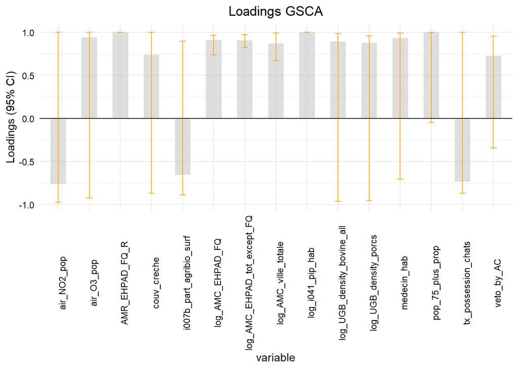

```r
# loadings bootstrap
boot_load <- boot_load[,-1]
IC_low <- c()
IC_high <- c()
for (i in 1:nrow(boot_load)){
  Q <- quantile(boot_load[i,], probs = c(0.025, 0.975))
  IC_low <- c(IC_low, Q[1])
  IC_high <- c(IC_high, Q[2])
}

loadings <- data.frame(
  variable = c(
    "AMR_EHPAD_FQ_R",
    "log_AMC_EHPAD_FQ",
    "log_AMC_ville_totale",
    "log_AMC_EHPAD_tot_except_FQ",
    "log_i041_pip_hab",
    "veto_by_AC",
    "medecin_hab",
    "couv_creche",
    "tx_possession_chats",
    "pop_75_plus_prop",
    "air_NO2_pop",
    "air_O3_pop",
    "log_UGB_density_bovine_all",
    "log_UGB_density_porcs",
    "i007b_part_agribio_surf"
  ),
  loading = mod$mC,
  CI_95_low = IC_low,
  CI_95_high = IC_high
)

ggplot(loadings) +
  geom_bar(aes(x = variable, y = loading), stat  = "identity", fill = "grey", width = 0.5, alpha = 0.5) +
  ggtitle("Loadings GSCA") +
  geom_errorbar(aes(x = variable, ymin= CI_95_low, ymax = CI_95_high), width=0.2, colour="orange", alpha=0.9) +
  geom_hline(yintercept = 0, color='black') +
  theme_minimal()+
  labs(y = "Loadings (95% CI)")+
  theme(axis.text = element_text(color = "black"),
        axis.text.x = element_text(angle = 90),
        plot.title = element_text(hjust = 0.5))
```

```r
kbl(loadings) %>% kable_classic(full_width = F, position = "left")
```

| variable | loading | CI_95_low | CI_95_high |
| --- | --- | --- | --- |
| AMR_EHPAD_FQ_R | 1.0000000 | 1.0000000 | 1.0000000 |
| log_AMC_EHPAD_FQ | 0.9103243 | 0.7352858 | 0.9622867 |
| log_AMC_ville_totale | 0.8701065 | 0.6711331 | 0.9888281 |
| log_AMC_EHPAD_tot_except_FQ | 0.9066639 | 0.8269285 | 0.9728112 |
| log_i041_pip_hab | 1.0000000 | 1.0000000 | 1.0000000 |
| veto_by_AC | 0.7268530 | -0.3431600 | 0.9541071 |
| medecin_hab | 0.9320105 | -0.7057003 | 0.9914391 |
| couv_creche | 0.7405777 | -0.8710051 | 0.9990802 |
| tx_possession_chats | -0.7337962 | -0.8684001 | 0.9971975 |
| pop_75_plus_prop | 1.0000000 | -0.0500000 | 1.0000000 |
| air_NO2_pop | -0.7606225 | -0.9732069 | 0.9973536 |
| air_O3_pop | 0.9421367 | -0.9218707 | 0.9987720 |
| log_UGB_density_bovine_all | 0.8900835 | -0.9622875 | 0.9866618 |
| log_UGB_density_porcs | 0.8806734 | -0.9530985 | 0.9611622 |
| i007b_part_agribio_surf | -0.6540869 | -0.8881481 | 0.8958940 |

```r
# Les R2 par blocs
r2 <- data.frame(
  var = c("Y", "AMC", "socioeco",
          "soin", "lifestyle", "demo",
          "env", "agri"),
  R2 = mod$R2[1,]
)

kbl(r2) %>% kable_classic(full_width = F, position = "left")
```

| var | R2 |
| --- | --- |
| Y | 0.8847949 |
| AMC | 0.9425069 |
| socioeco | 0.9723691 |
| soin | 0.9762037 |
| lifestyle | 0.9784942 |
| demo | 0.9666878 |
| env | 0.9664410 |
| agri | 0.9252554 |

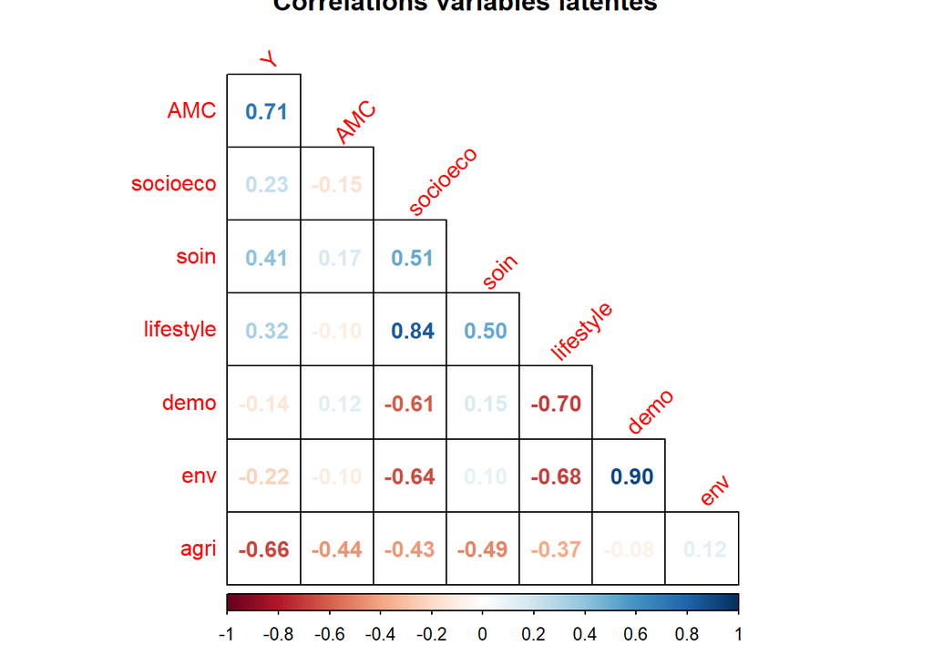

```r
# corrélation entre les variables latentes

latentcorr <- mod$latentcorr
rownames(latentcorr) <- c("Y", "AMC", "socioeco", "soin", "lifestyle", "demo", "env", "agri")
colnames(latentcorr) <- c("Y", "AMC", "socioeco", "soin", "lifestyle", "demo", "env", "agri")


corrplot::corrplot(latentcorr,
                   type = "lower",
                   method = "number",
                   diag = FALSE,
                   bg = "white",
                   addgrid.col = "black",
                   tl.srt = 45,
                   title = "Corrélations variables latentes")
```

```r
# corrélation entre les variables latentes et les variables de leurs blocs respectifs (tableau publi Stephanie)

# WR <- mod$WR
# X <- as.matrix(dat.func1[, c(1, 3, 17, 20, 21, 25, 26, 27, 28)])
# latent <- X%*%WR
#
# c1 <- cor(X[,1], latent[,1])
# c2 <- (cor(X[,2], latent[,2])^2+cor(X[,3], latent[,2])^2)/2
# c3 <- (cor(X[,4], latent[,3])^2+cor(X[,5], latent[,3])^2)/2
# c4 <- (cor(X[,6], latent[,4])^2+cor(X[,7], latent[,4])^2)/2
# c5 <- (cor(X[,8], latent[,5])^2+cor(X[,9], latent[,5])^2)/2
#
# t <- data.frame(block = rownames(latentcorr),
#                 meas_struct_sheme = c(c1, c2, c3, c4, c5))
#
# knitr::kable(t)
```

## 4.2 AMR_ES_FQ_R

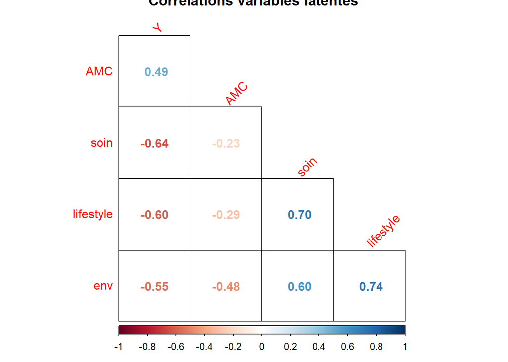

```r
dat.func2 <- openxlsx::read.xlsx("sum.var_AMR_ES_FQ_R.xlsx")
rownames(dat.func2) <- dat.func2[, 1]
dat.func2 <- dat.func2[,-1]

dat.func2 <- scale(dat.func2) # standardisation

MyModel <- paste(
  paste("Y =~", colnames(dat.func2)[1]),
  "AMC =~ log_AMC_ES_FQ + log_AMC_ville_totale",
  "soin =~ veto_by_CV + APL_medG",
  "lifestyle =~ prop_appart + tx_possession_chats",
  "env =~ air_NO2_pop + air_O3_pop",
  "Y ~ AMC + soin + lifestyle + env",
  sep = "\n\t\t"
)

mod <- gesca::gesca.run(MyModel, dat.func2, nbt = 0)
#summary(mod)

# corrélation entre les variables latentes

latentcorr <- mod$latentcorr
rownames(latentcorr) <- c("Y", "AMC", "soin", "lifestyle", "env")
colnames(latentcorr) <- c("Y", "AMC", "soin", "lifestyle", "env")


corrplot::corrplot(latentcorr,
                   type = "lower",
                   method = "number",
                   diag = FALSE,
                   bg = "white",
                   addgrid.col = "black",
                   tl.srt = 45,
                   title = "Corrélations variables latentes")
```

```r
# corrélation entre les variables latentes et les variables de leurs blocs respectifs (tableau publi Stephanie)

WR <- mod$WR
X <- as.matrix(dat.func2[, c(1, 9, 17, 26, 27, 29, 31, 38, 39)])
latent <- X%*%WR

c1 <- cor(X[,1], latent[,1])
c2 <- (cor(X[,2], latent[,2])^2+cor(X[,3], latent[,2])^2)/2
c3 <- (cor(X[,4], latent[,3])^2+cor(X[,5], latent[,3])^2)/2
c4 <- (cor(X[,6], latent[,4])^2+cor(X[,7], latent[,4])^2)/2
c5 <- (cor(X[,8], latent[,5])^2+cor(X[,9], latent[,5])^2)/2

t <- data.frame(block = rownames(latentcorr),
                meas_struct_sheme = c(c1, c2, c3, c4, c5))

knitr::kable(t)
```

| block | meas_struct_sheme |
| --- | --- |
| Y | 1.0000000 |
| AMC | 0.8023563 |
| soin | 0.5132550 |
| lifestyle | 0.8017649 |
| env | 0.6536721 |

## 4.3 AMR_ville_FQ_R

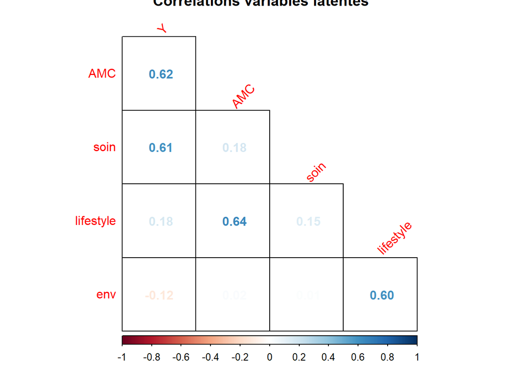

```r
dat.func3 <- openxlsx::read.xlsx("sum.var_AMR_ville_FQ_R.xlsx")
rownames(dat.func3) <- dat.func3[, 1]
dat.func3 <- dat.func3[,-1]

dat.func3 <- scale(dat.func3) # standardisation

MyModel <- paste(
  paste("Y =~", colnames(dat.func3)[1]),
  "AMC =~ log_AMC_ville_FQ + log_AMC_EHPAD_totale + log_AMC_ES_totale",
  "soin =~ veto_by_AC + medecin_hab + prop_veto_50plus",
  "lifestyle =~ prop_tabagisme + tx_possession_chats",
  "env =~ air_NO2_pop + resid_FQ_eau_naiades",
  "Y ~ AMC + soin + lifestyle + env",
  sep = "\n\t\t"
)

mod <- gesca::gesca.run(MyModel, dat.func3, nbt = 0)
#summary(mod)

# corrélation entre les variables latentes

latentcorr <- mod$latentcorr
rownames(latentcorr) <- c("Y", "AMC", "soin", "lifestyle", "env")
colnames(latentcorr) <- c("Y", "AMC", "soin", "lifestyle", "env")


corrplot::corrplot(latentcorr,
                   type = "lower",
                   method = "number",
                   diag = FALSE,
                   bg = "white",
                   addgrid.col = "black",
                   tl.srt = 45,
                   title = "Corrélations variables latentes")
```

```r
# corrélation entre les variables latentes et les variables de leurs blocs respectifs (tableau publi Stephanie)

WR <- mod$WR
X <- as.matrix(dat.func3[, c(1, 13, 8, 11, 28, 33, 31, 34, 35, 41, 45)])
latent <- X%*%WR

c1 <- cor(X[,1], latent[,1])
c2 <- (cor(X[,2], latent[,2])^2+cor(X[,3], latent[,2])^2+cor(X[,4], latent[,2])^2)/3
c3 <- (cor(X[,5], latent[,3])^2+cor(X[,6], latent[,3])^2+cor(X[,7], latent[,3])^2)/3
c4 <- (cor(X[,8], latent[,4])^2+cor(X[,9], latent[,4])^2)/2
c5 <- (cor(X[,10], latent[,5])^2+cor(X[,11], latent[,5])^2)/2

t <- data.frame(block = rownames(latentcorr),
                meas_struct_sheme = c(c1, c2, c3, c4, c5))

knitr::kable(t)
```

| block | meas_struct_sheme |
| --- | --- |
| Y | 1.0000000 |
| AMC | 0.5645926 |
| soin | 0.2261801 |
| lifestyle | 0.5505276 |
| env | 0.6030282 |

## 4.4 AMR_EHPAD_C3G_R

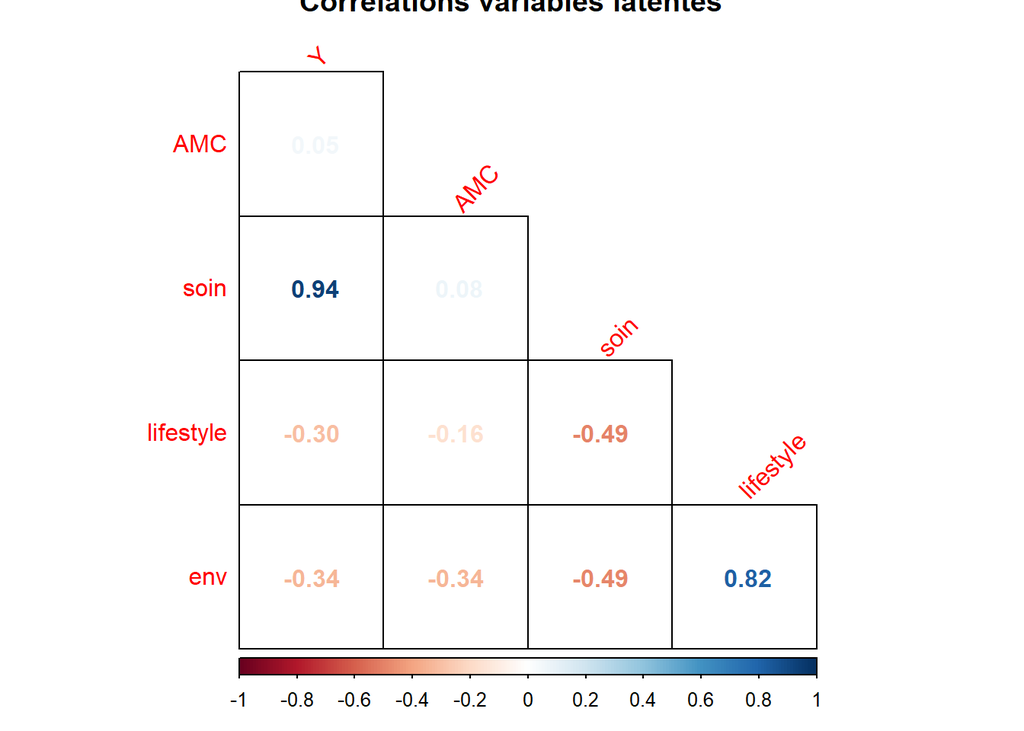

```r
dat.func4 <- openxlsx::read.xlsx("sum.var_AMR_EHPAD_C3G_R.xlsx")
rownames(dat.func4) <- dat.func4[, 1]
dat.func4 <- dat.func4[,-1]

dat.func4 <- scale(dat.func4) # standardisation

MyModel <- paste(
  paste("Y =~", colnames(dat.func4)[1]),
  "AMC =~ log_AMC_EHPAD_C3G + log_AMC_ES_totale",
  "soin =~ veto_by_CV + APL_medG",
  "lifestyle =~ prop_alcool + tx_possession_chats",
  "env =~ air_NO2_pop + air_O3_pop",
  "Y ~ AMC + soin + lifestyle + env",
  sep = "\n\t\t"
)

mod <- gesca::gesca.run(MyModel, dat.func4, nbt = 0)
#summary(mod)

# corrélation entre les variables latentes

latentcorr <- mod$latentcorr
rownames(latentcorr) <- c("Y", "AMC", "soin", "lifestyle", "env")
colnames(latentcorr) <- c("Y", "AMC", "soin", "lifestyle", "env")


corrplot::corrplot(latentcorr,
                   type = "lower",
                   method = "number",
                   diag = FALSE,
                   bg = "white",
                   addgrid.col = "black",
                   tl.srt = 45,
                   title = "Corrélations variables latentes")
```

```r
# corrélation entre les variables latentes et les variables de leurs blocs respectifs (tableau publi Stephanie)

WR <- mod$WR
X <- as.matrix(dat.func4[, c(1, 2, 10, 20, 21, 23, 25, 30, 31)])
latent <- X%*%WR

c1 <- cor(X[,1], latent[,1])
c2 <- (cor(X[,2], latent[,2])^2+cor(X[,3], latent[,2])^2)/2
c3 <- (cor(X[,4], latent[,3])^2+cor(X[,5], latent[,3])^2)/2
c4 <- (cor(X[,6], latent[,4])^2+cor(X[,7], latent[,4])^2)/2
c5 <- (cor(X[,8], latent[,5])^2+cor(X[,9], latent[,5])^2)/2

t <- data.frame(block = rownames(latentcorr),
                meas_struct_sheme = c(c1, c2, c3, c4, c5))

knitr::kable(t)
```

| block | meas_struct_sheme |
| --- | --- |
| Y | 1.0000000 |
| AMC | 0.7276660 |
| soin | 0.4990187 |
| lifestyle | 0.5573162 |
| env | 0.6558777 |

## 4.5 AMR_ES_C3G_R

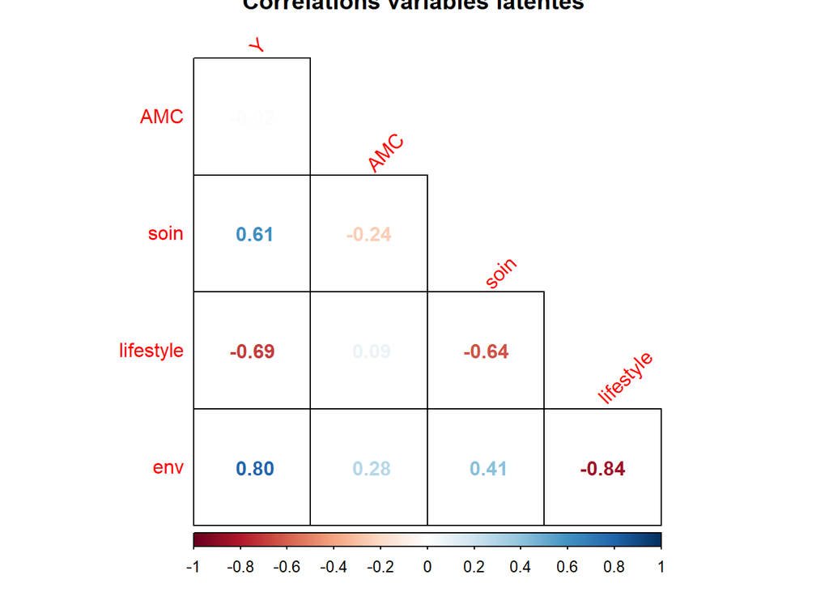

```r
dat.func5 <- openxlsx::read.xlsx("sum.var_AMR_ES_C3G_R.xlsx")
rownames(dat.func5) <- dat.func5[, 1]
dat.func5 <- dat.func5[,-1]

dat.func5 <- scale(dat.func5) # standardisation

MyModel <- paste(
  paste("Y =~", colnames(dat.func5)[1]),
  "AMC =~ log_AMC_EHPAD_C3G + log_AMC_ES_totale",
  "soin =~ veto_by_CV + veto_by_AC",
  "lifestyle =~ prop_appart + tx_possession_chats",
  "env =~ air_NO2_pop + air_O3_pop",
  "Y ~ AMC + soin + lifestyle + env",
  sep = "\n\t\t"
)

mod <- gesca::gesca.run(MyModel, dat.func5, nbt = 0)
#summary(mod)

# corrélation entre les variables latentes

latentcorr <- mod$latentcorr
rownames(latentcorr) <- c("Y", "AMC", "soin", "lifestyle", "env")
colnames(latentcorr) <- c("Y", "AMC", "soin", "lifestyle", "env")


corrplot::corrplot(latentcorr,
                   type = "lower",
                   method = "number",
                   diag = FALSE,
                   bg = "white",
                   addgrid.col = "black",
                   tl.srt = 45,
                   title = "Corrélations variables latentes")
```

```r
# corrélation entre les variables latentes et les variables de leurs blocs respectifs (tableau publi Stephanie)

WR <- mod$WR
X <- as.matrix(dat.func5[, c(1, 2, 9, 26, 25, 30, 32, 34, 35)])
latent <- X%*%WR

c1 <- cor(X[,1], latent[,1])
c2 <- (cor(X[,2], latent[,2])^2+cor(X[,3], latent[,2])^2)/2
c3 <- (cor(X[,4], latent[,3])^2+cor(X[,5], latent[,3])^2)/2
c4 <- (cor(X[,6], latent[,4])^2+cor(X[,7], latent[,4])^2)/2
c5 <- (cor(X[,8], latent[,5])^2+cor(X[,9], latent[,5])^2)/2

t <- data.frame(block = rownames(latentcorr),
                meas_struct_sheme = c(c1, c2, c3, c4, c5))

knitr::kable(t)
```

| block | meas_struct_sheme |
| --- | --- |
| Y | 1.0000000 |
| AMC | 0.7936768 |
| soin | 0.5862298 |
| lifestyle | 0.7341678 |
| env | 0.7025809 |

## 4.6 AMR_ville_C3G_R

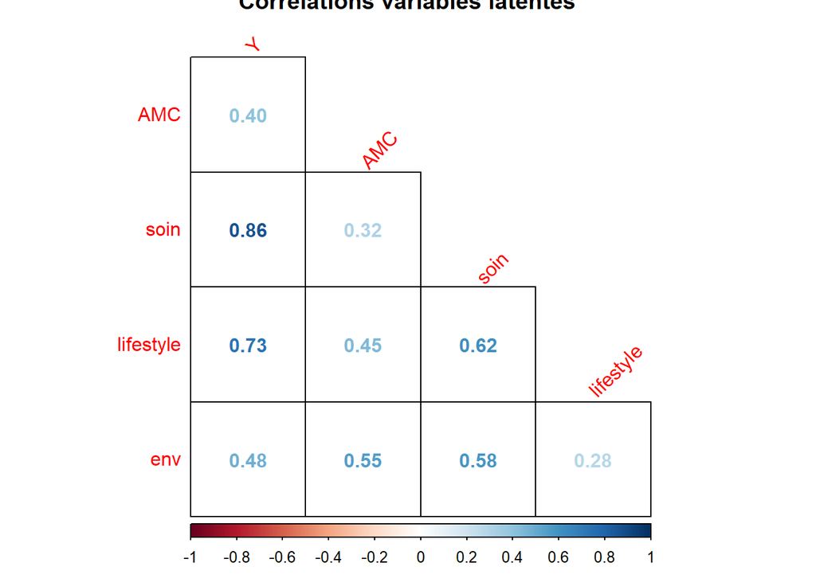

```r
dat.func6 <- openxlsx::read.xlsx("sum.var_AMR_ville_C3G_R.xlsx")
rownames(dat.func6) <- dat.func6[, 1]
dat.func6 <- dat.func6[,-1]

dat.func6 <- scale(dat.func6) # standardisation

MyModel <- paste(
  paste("Y =~", colnames(dat.func6)[1]),
  "AMC =~ log_AMC_ville_totale + log_AMC_ES_totale",
  "soin =~ veto_by_CV + APL_medG",
  "lifestyle =~ prop_tabagisme + couv_creche",
  "env =~ air_NO2_pop + air_O3_pop",
  "Y ~ AMC + soin + lifestyle + env",
  sep = "\n\t\t"
)

mod <- gesca::gesca.run(MyModel, dat.func6, nbt = 0)
#summary(mod)

# corrélation entre les variables latentes

latentcorr <- mod$latentcorr
rownames(latentcorr) <- c("Y", "AMC", "soin", "lifestyle", "env")
colnames(latentcorr) <- c("Y", "AMC", "soin", "lifestyle", "env")


corrplot::corrplot(latentcorr,
                   type = "lower",
                   method = "number",
                   diag = FALSE,
                   bg = "white",
                   addgrid.col = "black",
                   tl.srt = 45,
                   title = "Corrélations variables latentes")
```

```r
# corrélation entre les variables latentes et les variables de leurs blocs respectifs (tableau publi Stephanie)

WR <- mod$WR
X <- as.matrix(dat.func6[, c(1, 11, 8, 26, 19, 22, 23, 24, 25)])
latent <- X%*%WR

c1 <- cor(X[,1], latent[,1])
c2 <- (cor(X[,2], latent[,2])^2+cor(X[,3], latent[,2])^2)/2
c3 <- (cor(X[,4], latent[,3])^2+cor(X[,5], latent[,3])^2)/2
c4 <- (cor(X[,6], latent[,4])^2+cor(X[,7], latent[,4])^2)/2
c5 <- (cor(X[,8], latent[,5])^2+cor(X[,9], latent[,5])^2)/2

t <- data.frame(block = rownames(latentcorr),
                meas_struct_sheme = c(c1, c2, c3, c4, c5))

knitr::kable(t)
```

| block | meas_struct_sheme |
| --- | --- |
| Y | 1.0000000 |
| AMC | 0.7106039 |
| soin | 0.7503519 |
| lifestyle | 0.6615564 |
| env | 0.6558693 |